# Lecture 7. Data visualization - Dates and times

Carlos Ramirez Alvarez

9/16/2019

Plotting changes in values over time is important to see dynamical patterns. Using time and dates is a crucial skill. In biomedical science is common to have sample records tagged with date information. Dates and times are commonly given in the form of a string or text in a column of a table of records. Here we will see how to handle dates with some real life final example plotting magnitude and deep of tremors in Mexico.

## Handling date and times

In order to use character string dates as a continous time axis they must be interpreted or casted to date objects. There are two types of data objects in R:

- POSIXlt - based on a list.
- POSIXct - essentially a integer given in UNIX Epoch time.

Don’t bother to much with these definitions since both objects can be converted into each other and the recommendation is to use the one that easily fits your needs.

Let’s use Sys.time() to get the date and time in our computer:

```r
time <- Sys.time()
time
```

```
## [1] "2019-09-28 17:08:22 CDT"
```

```r
class(time)
```

```
## [1] "POSIXct" "POSIXt"
```

## as.Date() - coerce string to date-time.

Some simple formats can be coerced in a straightforward manner using as.Date(). For example, ‘2019-09-20’.

```r
date <- as.Date('2019-09-20')
```

Unfortunately, dates and times are given in many formats. Hence, in the next section we will see how to manipulate dates and times formats.

## Date and times formats

strptime() function parses strings into dates. It takes the following two parameters:

- date - as a string character o string vector.
- format - a string indicating the format of the date.

This would be clear by using examples.

```r
strptime('Septiembre 20, 2019 17:40', "%B %d, %Y %H:%M")
```

```
## [1] "2019-09-20 17:40:00 CDT"
```

In the second string argument passed to strptime() `"%B %d, %Y %H:%M"`, the percentage symbol `%` followed by a character represents a time unit given in a specific format. For example `%B` represents months given as whole text name whilst `%d` represents days in number format. You don’t need to remember all possible string formats, instead it is advisable to consult documentation using ?strptime.

Let’s see another example formats. Note the difference for the separators.

```r
strptime('20/Sep/2019 17:40', "%d/%b/%Y %H:%M")
```

```
## [1] "2019-09-20 17:40:00 CDT"
```

Let’s see another example formats.

```r
strptime('20 Septiembre 2019', "%d %B %Y")
```

```
## [1] "2019-09-20 CDT"
```

```r
strptime('2019:09:20 17:40', "%Y:%m:%d %H:%M")
```

```
## [1] "2019-09-20 17:40:00 CDT"
```

## Lubridate Package for handling dates

Lubridate R package can be used to manage dates and times by using generic functions without the need of passing string formats patterns as in strptime.

```r
library(lubridate)
```

We wil parse the previous defined strings to dates using lubridate. We can transform the string `'20/Sep/2019 17:40'` to date by using the function dmy_hm() which means day-month-year_hour-minute.

```r
dmy_hm('20/Sep/2019 17:40')
```

```
## [1] "2019-09-20 17:40:00 UTC"
```

Another example.

```r
dmy('20 Septiembre 2019')
```

```
## [1] "2019-09-20"
```

Note that we don’t need to specify the format and lubridate is able to figure out how to interpret dates.

```r
ymd_hm('2019:09:20 17:40')
```

```
## [1] "2019-09-20 17:40:00 UTC"
```

You can handle allmost all type of dates and times formats with lubridate by using combinations of d-m-y and h-m-s. Lubridates also provides a clear and easy to remember syntaxis.

## Historical records of tremors in Mexico

We will look at the data from the Sismologico Nacional recording magnitud and deep of tremors registered in Mexico.

Our goal is to visualize the pattern of magnitud of tremors during the last year.

First, we will load the data into R.

```r
## Find the data in http://www2.ssn.unam.mx:8080/catalogo/
url <- 'https://raw.githubusercontent.com/caramirezal/dataScience/master/data/tremors.csv'
tremors <- read.csv(url,
                    skip = 4,
                    header = TRUE,
                    stringsAsFactors = FALSE)
tremors <- tremors[complete.cases(tremors),]
str(tremors)
```

```
## 'data.frame':    157885 obs. of  10 variables:
##  $ Fecha                     : chr  "1985-01-01" "1985-01-01" "1985-01-01" "1985-01-01" ...
##  $ Hora                      : chr  "00:51:59" "01:08:39" "07:12:01" "08:25:34" ...
##  $ Magnitud                  : chr  "no calculable" "no calculable" "no calculable" "no calculable" ...
##  $ Latitud                   : num  15.9 18 15.7 15.3 16.1 ...
##  $ Longitud                  : num  -98.7 -102 -94.3 -94.5 -98.4 ...
##  $ Profundidad               : chr  "33.0" "33.0" "33.0" "33.0" ...
##  $ Referencia.de.localizacion: chr  "86 km al SUROESTE de PINOTEPA NACIONAL, OAX" "22 km al ESTE de CD LAZARO CARDENAS, MICH" "70 km al SUROESTE de TONALA, CHIS" "115 km al SUROESTE de TONALA, CHIS" ...
##  $ Fecha.UTC                 : chr  "1985-01-01" "1985-01-01" "1985-01-01" "1985-01-01" ...
##  $ Hora.UTC                  : chr  "06:51:59" "07:08:39" "13:12:01" "14:25:34" ...
##  $ Estatus                   : chr  "revisado" "revisado" "revisado" "revisado" ...
```

We will use dplyr functions to process the data.

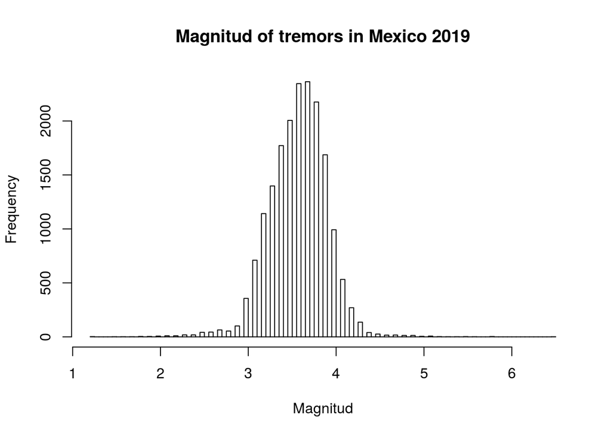

```r
library(dplyr)

## Processing the data
tremors.p <- tremors %>%
              mutate(
                      Fecha_Hora = paste(Fecha, Hora),  ## paste data and time cols
                      time = ymd_hms(Fecha_Hora),       ## parsing time with lubridate
                      Magnitud = as.numeric(Magnitud)   ## casting value to numeric
                     ) %>%
             filter(time > '2019-01-01' & ! is.na(Magnitud))

## Plotting magnitude histogram
with(tremors.p,
     hist(Magnitud, breaks = 100,
          main = 'Magnitud of tremors in Mexico 2019'))
```

Note that we use `time > '2019-01-01'` in the filter function to obtain records in 2019. You can use *<*, *>* and *=* algebraic operators to define time intervals.

From the plot it can be seen that the vast majority of tremors is around ~3.6.